# Regression Models - Quiz 4

Delermando Branquinho Filho

20 de julho de 2016

## Question 1

Consider the space shuttle data ?shuttle in the MASS library. Consider modeling the use of the autolander as the outcome (variable name use). Fit a logistic regression model with autolander (variable auto) use (labeled as “auto” 1) versus not (0) as predicted by wind sign (variable wind). Give the estimated odds ratio for autolander use comparing head winds, labeled as “head” in the variable headwind (numerator) to tail winds (denominator).

```r
library(MASS)
head(shuttle)
```

```
##   stability error sign wind   magn vis  use
## 1     xstab    LX   pp head  Light  no auto
## 2     xstab    LX   pp head Medium  no auto
## 3     xstab    LX   pp head Strong  no auto
## 4     xstab    LX   pp tail  Light  no auto
## 5     xstab    LX   pp tail Medium  no auto
## 6     xstab    LX   pp tail Strong  no auto
```

```r
shuttle2<-shuttle
shuttle2$use2<-as.numeric(shuttle2$use=='auto')
fit<-glm(use2 ~ factor(wind) - 1, family = binomial, data = shuttle2)
fit
```

```
##
## Call:  glm(formula = use2 ~ factor(wind) - 1, family = binomial, data = shuttle2)
##
## Coefficients:
## factor(wind)head  factor(wind)tail
##           0.2513            0.2831
##
## Degrees of Freedom: 256 Total (i.e. Null);  254 Residual
## Null Deviance:       354.9
## Residual Deviance: 350.3     AIC: 354.3
```

```r
fit<-glm(use2 ~ factor(wind) - 1, family = binomial, data = shuttle2)
shuttle2<-shuttle
shuttle2$use2<-as.numeric(shuttle2$use=='auto')
fit<-glm(use2 ~ factor(wind) - 1, family = binomial, data = shuttle2)
summary(fit)$coef
```

```
##                   Estimate Std. Error  z value  Pr(>|z|)
## factor(wind)head 0.2513144  0.1781742 1.410499 0.1583925
## factor(wind)tail 0.2831263  0.1785510 1.585689 0.1128099
```

```r
exp(coef(fit))
```

```
## factor(wind)head factor(wind)tail
##         1.285714         1.327273
```

```r
1.286 / 1.327
```

```
## [1] 0.9691032
```

```r
# ou
exp(coef(fit))[1] / exp(coef(fit))[2]
```

```
## factor(wind)head
##        0.9686888
```

```r
exp(cbind(OddsRatio = coef(fit), confint(fit)))
```

```
##                  OddsRatio     2.5 %   97.5 %
## factor(wind)head  1.285714 0.9082416 1.829382
## factor(wind)tail  1.327273 0.9372106 1.890548
```

## Question 2

Consider the previous problem. Give the estimated odds ratio for autoloader use comparing head winds (numerator) to tail winds (denominator) adjusting for wind strength from the variable mag

```r
fit<-glm(use2 ~ factor(wind) + factor(magn) - 1, family = binomial, data = shuttle2)
summary(fit)$coef
```

```
##                         Estimate Std. Error       z value  Pr(>|z|)
## factor(wind)head    3.635093e-01  0.2840608  1.279688e+00 0.2006547
## factor(wind)tail    3.955180e-01  0.2843987  1.390717e+00 0.1643114
## factor(magn)Medium -1.009525e-15  0.3599481 -2.804642e-15 1.0000000
## factor(magn)Out    -3.795136e-01  0.3567709 -1.063746e+00 0.2874438
## factor(magn)Strong -6.441258e-02  0.3589560 -1.794442e-01 0.8575889
```

```r
exp(coef(fit))
```

```
##   factor(wind)head   factor(wind)tail factor(magn)Medium
##          1.4383682          1.4851533          1.0000000
##    factor(magn)Out factor(magn)Strong
##          0.6841941          0.9376181
```

```r
exp(cbind(OddsRatio = coef(fit), confint(fit)))
```

```
##                    OddsRatio     2.5 %   97.5 %
## factor(wind)head   1.4383682 0.8281020 2.534603
## factor(wind)tail   1.4851533 0.8548293 2.619816
## factor(magn)Medium 1.0000000 0.4928642 2.028956
## factor(magn)Out    0.6841941 0.3380374 1.373844
## factor(magn)Strong 0.9376181 0.4627029 1.897218
```

```r
exp(cbind(OddsRatio = coef(fit), confint(fit)))[1] / exp(cbind(OddsRatio = coef(fit), confint(fit)))[2]
```

```
## [1] 0.9684981
```

## Question 3

```r
fit<-glm(use2 ~ factor(wind), family = binomial, data = shuttle2)
summary(fit)$coef
```

```
##                    Estimate Std. Error   z value  Pr(>|z|)
## (Intercept)      0.25131443  0.1781742 1.4104987 0.1583925
## factor(wind)tail 0.03181183  0.2522429 0.1261159 0.8996402
```

```r
fit<-glm(1 - use2 ~ factor(wind), family = binomial, data = shuttle2)
summary(fit)$coef
```

```
##                     Estimate Std. Error    z value  Pr(>|z|)
## (Intercept)      -0.25131443  0.1781742 -1.4104987 0.1583925
## factor(wind)tail -0.03181183  0.2522429 -0.1261159 0.8996402
```

The coefficients reverse their signs.

## Question 4

Consider the insect spray data InsectSprays . Fit a Poisson model using spray as a factor level. Report the estimated relative rate comapring spray A (numerator) to spray B (denominator).

```r
fit <- glm(count ~ relevel(spray, "B"), data = InsectSprays, family = poisson)
exp(coef(fit))[2]
```

```
## relevel(spray, "B")A
##            0.9456522
```

## Question 5

Consider a Poisson glm with an offset, t. So, for example, a model of the form glm(count ~ x + offset(t), family = poisson) where x is a factor variable comparing a treatment (1) to a control (0) and t is the natural log of a monitoring time. What is impact of the coefficient for x if we fit the model glm(count ~ x + offset(t2), family = poisson) where 2 <- log(10) + t? In other words, what happens to the coefficients if we change the units of the offset variable. (Note, adding log(10) on the log scale is multiplying by 10 on the original scale.)

```r
fit<-glm(count ~ factor(spray), family = poisson,data=InsectSprays,offset = log(count + 1))
summary(fit)$coef
```

```
##                    Estimate Std. Error     z value  Pr(>|z|)
## (Intercept)    -0.066691374  0.0758098 -0.87971965 0.3790112
## factor(spray)B  0.003512473  0.1057445  0.03321659 0.9735019
## factor(spray)C -0.325350713  0.2138857 -1.52114274 0.1282240
## factor(spray)D -0.118451059  0.1506528 -0.78625173 0.4317200
## factor(spray)E -0.184623054  0.1719205 -1.07388635 0.2828736
## factor(spray)F  0.008422466  0.1036683  0.08124434 0.9352476
```

```r
fit2<-glm(count ~ factor(spray), family = poisson,data=InsectSprays,offset = log(10)+log(count+1))
summary(fit2)$coef
```

```
##                    Estimate Std. Error      z value      Pr(>|z|)
## (Intercept)    -2.369276467  0.0758098 -31.25290307 2.038695e-214
## factor(spray)B  0.003512473  0.1057445   0.03321659  9.735019e-01
## factor(spray)C -0.325350713  0.2138857  -1.52114274  1.282240e-01
## factor(spray)D -0.118451059  0.1506528  -0.78625173  4.317200e-01
## factor(spray)E -0.184623054  0.1719205  -1.07388635  2.828736e-01
## factor(spray)F  0.008422466  0.1036683   0.08124434  9.352476e-01
```

```r
fit<-glm(count ~ factor(spray) + offset(log(count+1)), family = poisson,data=InsectSprays)
summary(fit)$coef
```

```
##                    Estimate Std. Error     z value  Pr(>|z|)
## (Intercept)    -0.066691374  0.0758098 -0.87971965 0.3790112
## factor(spray)B  0.003512473  0.1057445  0.03321659 0.9735019
## factor(spray)C -0.325350713  0.2138857 -1.52114274 0.1282240
## factor(spray)D -0.118451059  0.1506528 -0.78625173 0.4317200
## factor(spray)E -0.184623054  0.1719205 -1.07388635 0.2828736
## factor(spray)F  0.008422466  0.1036683  0.08124434 0.9352476
```

```r
fit2<-glm(count ~ factor(spray) + offset(log(10)+log(count+1)), family = poisson,data=InsectSprays)
summary(fit2)$coef
```

```
##                    Estimate Std. Error      z value      Pr(>|z|)
## (Intercept)    -2.369276467  0.0758098 -31.25290307 2.038695e-214
## factor(spray)B  0.003512473  0.1057445   0.03321659  9.735019e-01
## factor(spray)C -0.325350713  0.2138857  -1.52114274  1.282240e-01
## factor(spray)D -0.118451059  0.1506528  -0.78625173  4.317200e-01
## factor(spray)E -0.184623054  0.1719205  -1.07388635  2.828736e-01
## factor(spray)F  0.008422466  0.1036683   0.08124434  9.352476e-01
```

## Question 6

Consider the data

```r
x <- -5:5
y <- c(5.12, 3.93, 2.67, 1.87, 0.52, 0.08, 0.93, 2.05, 2.54, 3.87, 4.97)
```

Using a knot point at 0, fit a linear model that looks like a hockey stick with two lines meeting at x=0. Include an intercept term, x and the knot point term. What is the estimated slope of the line after 0?

```r
x <- -5:5
y <- c(5.12, 3.93, 2.67, 1.87, 0.52, 0.08, 0.93, 2.05, 2.54, 3.87, 4.97)

knots<-c(0)
splineTerms<-sapply(knots,function(knot) (x>knot)*(x-knot))
xmat<-cbind(1,x,splineTerms)
fit<-lm(y~xmat-1)
yhat<-predict(fit)
summary(fit)$coef
```

```
##         Estimate Std. Error    t value     Pr(>|t|)
## xmat  -0.1825806 0.13557812  -1.346682 2.149877e-01
## xmatx -1.0241584 0.04805280 -21.313188 2.470198e-08
## xmat   2.0372258 0.08574713  23.758531 1.048711e-08
```

```r
(yhat[10]-yhat[6])/4
```

```
##       10
## 1.013067
```

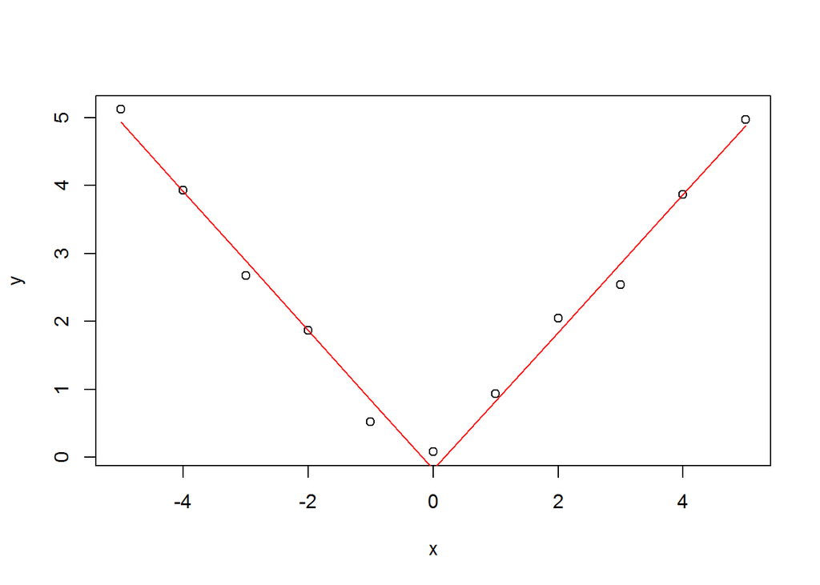

```r
plot(x,y)
lines(x,yhat,col="red")
```